# Satisfaction Prediction through Text Analysis of Automobile Manufacturer Reviews

Businesses today, including vehicle manufacturers and brands like Toyota, Ford, and Honda, solicit reviews at every opportunity. I propose that by utilizing the text from consumer reviews, I can predict overall satisfaction ratings. A vehicle manufacturer would be interested in this information to help identify signs of dissatisfaction, anticipate vehicle reliability concerns, and gauge brand loyalty.

The dataset that I have selected was sourced from Kaggle and fits the goals of my analysis: “https://www.kaggle.com/datasets/ankkur13/edmundsconsumer-car-ratings-and-reviews%E2%80%9D

This dataset is a trove of information from 62 vehicle manufacturers and brands. While analysis of every brand and manufacturer would be ideal, I will limit my analysis to a brand near and dear to me, Honda. I’ve selected Honda because of my own personal familiarity, ownership, and simply because it interests me more than the others.

Of the Kaggle datasets, the “Scrapped_Car_reviews_Honda” dataset is the one I will be analyzing, as it is the one related to Honda specifically. This dataset contains the variables “Review_Date”, “Author_Name”, “Vehicle_Title”, “Review_Title”, “Review”, and “Rating”. There is also an unnamed column that heads off the dataset. This column is what I assume to be the review number, which starts with 0 in column A.

The “Rating” variable will be my target variable, as this is what I am trying to predict. “Rating” is the numerical representation of the reviewer's satisfaction. “Rating” will be what my model is trained to predict using the text of the “Review” variable. This analysis will give Honda insight, maybe even a prediction, on how the reviewers' textual language relates to overall satisfaction.

The model most fit for this analysis is text regression. I plan to establish my baseline dataset with TF-IDF vectorization and Ridge Regression. TF-IDF to convert text into numerical vectors and capture word importance across the dataset. Ridge Regression to predict the “Rating” value, which represents overall satisfaction.

The benefits of these are that they are quick to train, a benefit to all vehicle manufacturers and brands seeking quick insight, and they are great for ease of interpretation. This approach enables vehicle manufacturers to identify which words, phrases, etc., are most associated with a high and low “Rating”, and to generate deeper insights from feedback.

```python
import pandas as pd

# Load the Honda dataset
df = pd.read_csv('Scrapped_Car_Reviews_Honda.csv', engine='python')

# Verify the data is correctly imported
print(df.head())

# Check for information and structure
print(df.info())
```

```
  Unnamed: 0                  Review_Date      Author_Name  \
0          0   on 03/01/17 13:11 PM (PST)      kris corah
1          1   on 09/02/16 18:22 PM (PDT)  Carol Shafford
2          2   on 11/12/15 08:04 AM (PST)            Gale
3          3   on 08/13/15 15:40 PM (PDT)    Judy Eastham
4          4   on 03/14/13 10:38 AM (PDT)  boeserkritiker

                                       Vehicle_Title  \
0  2007 Honda Element SUV LX 4dr SUV AWD (2.4L 4c...
1  2007 Honda Element SUV EX 4dr SUV AWD (2.4L 4c...
2  2007 Honda Element SUV EX 4dr SUV AWD (2.4L 4c...
3   2007 Honda Element SUV LX 4dr SUV (2.4L 4cyl 5M)
4   2007 Honda Element SUV LX 4dr SUV (2.4L 4cyl 5A)

                         Review_Title  \
0                QUIRKY AND PRACTICAL
1       Go Anywhere with your Element
2                    Such a cool car!
3  From soup to nuts, it does it all.
4                          good value

                                              Review  Rating
0   4 years with our element. Honestly there isn'...     4.0
1   I have owned my Element since 2007 when I pur...     5.0
2   Lowest maintenance of any vehicle I've ever o...     1.0
3   The only thing I'd change is the drink holder...     5.0
4   I bought this vehicle new in 2007. got 97K mi...     4.0
<class 'pandas.core.frame.DataFrame'>
RangeIndex: 14213 entries, 0 to 14212
Data columns (total 7 columns):
 #   Column         Non-Null Count  Dtype
---  ------         --------------  -----
 0   Unnamed: 0     14205 non-null  object
 1   Review_Date    12984 non-null  object
 2   Author_Name    12684 non-null  object
 3   Vehicle_Title  12684 non-null  object
 4   Review_Title   12681 non-null  object
 5   Review         12684 non-null  object
 6   Rating         12384 non-null  float64
dtypes: float64(1), object(6)
memory usage: 777.4+ KB
None
```

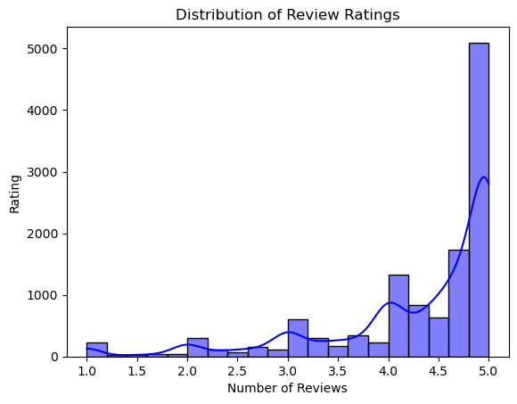

```python
import seaborn as sns
import matplotlib.pyplot as plt

sns.histplot(df['Rating'].dropna(), bins=20, kde=True, color='blue')
plt.title('Distribution of Review Ratings')
plt.ylabel('Rating')
plt.xlabel('Number of Reviews')
plt.show()
```

Explain: This histogram illustrates the frequency of review ratings from 1 to 5 for Honda vehicles. A majority of the ratings are clustered around 4.0 to 5.0, with a bias towards 5.0. A kernel density estimate overlays the bars, reinforcing the skew toward the 5.0 satisfaction.

Analyze: The presence of high ratings suggests that most reviewers are assigning a 5.0, the highest rating possible, which could reflect brand loyalty. However, there is a substantial presence of lower ratings from 4.0 and below. This is valuable information as it may start to explain signs of dissatisfaction, reliability concerns, and shifting loyalty, all of which are useful in solving the business problem.

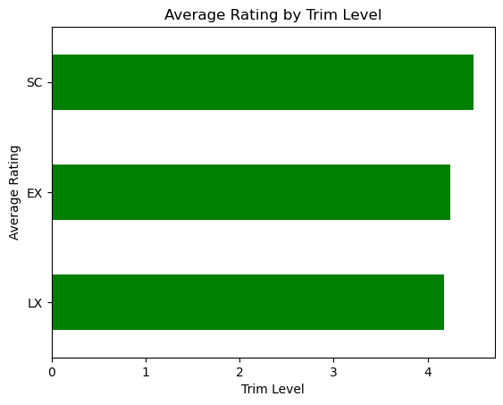

```python
df['Trim'] = df['Vehicle_Title'].str.extract(r'\b(EX|LX|SC)\b', expand=False)
trim_avg = df.dropna(subset=['Trim', 'Rating']).groupby('Trim')['Rating'].mean().sort_values()

trim_avg.plot(kind='barh', color='green')
plt.title('Average Rating by Trim Level')
plt.ylabel('Average Rating')
plt.xlabel('Trim Level')
plt.show()
```

Explain: This bar graph illustrates the average satisfaction rating across three Honda trim levels, SC, EX, and LX, that were extracted from "Vehicle_Title" using pattern matching. There may be additional trims in the dataset that are excluded due to formatting issues. In the future, I could improve trim level detection with a method like NLP or string similarity.

Analyze: SC leads in average satisfaction, then EX, and lastly LX. This suggests reviewers prefer the SC configuration, and maintaining this Time Level as an option may lead to more positive reviews. Further analysis may reveal which aspects of the SC Trim Level drive satisfaction.

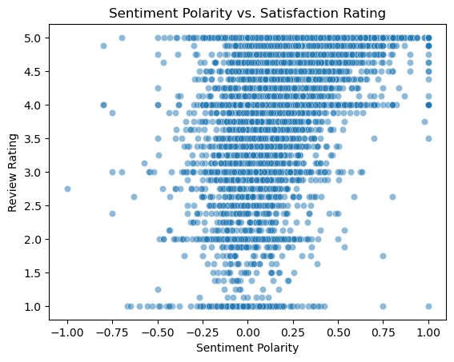

```python
from textblob import TextBlob

df_filtered = df.dropna(subset=['Review', 'Rating']).copy()
df_filtered['Sentiment_Polarity'] = df_filtered['Review'].apply(lambda x: TextBlob(str(x)).sentiment.polarity)

sns.scatterplot(data=df_filtered, x='Sentiment_Polarity', y='Rating', alpha=0.5)
plt.title('Sentiment Polarity vs. Satisfaction Rating')
plt.ylabel('Review Rating')
plt.xlabel('Sentiment Polarity')
plt.show()
```

Explain: This scatterplot illustrates the relationship between a review's sentiment polarity score and corresponding satisfaction rating. Each blue dot represents an individual review, and dots become denser near higher polarity and higher rating values.

Analyze: This scatter reveals a positive trend: reviews with higher sentiment polarity tend to trend with higher satisfaction ratings. This is shown by the clustering of dots around Sentiment Polarity of .2 to 1.0 and a Review Rating of 4.0 to 5.0, supporting the thought that consumer language can be a predictor of satisfaction. Unfortunately, there is a considerable number of dots and clusters all across this scatter. This implies that Sentiment Polarity is unlikely to solely depict the reviewer's intent. A future analysis could include TF-IDF weights so I can better capture review language.

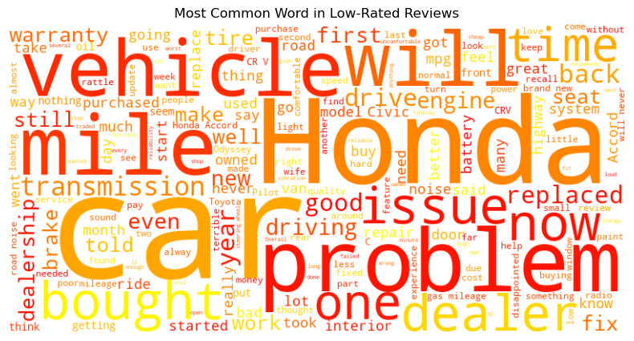

```python
from wordcloud import WordCloud

low_review = ' '.join(df[df['Rating'] <= 3]['Review'].dropna().astype(str))
wordcloud = WordCloud(width=800, height=400, background_color='white', colormap='autumn').generate(low_review)

plt.figure(figsize=(10, 5))
plt.imshow(wordcloud, interpolation='bilinear')
plt.axis('off')
plt.title('Most Common Word in Low-Rated Reviews')
plt.show()
```

Explain: This word cloud highlights the frequency of words in a reviewer's comment with an associated review rating of 3.0 or lower. Larger words are more frequently occurring and lend to themes in a reviewer's language choice.

Analyze: Putting aside the frequently occurring words like car, problem, Honda, and mile, there are many keyword standouts like transmission, warranty, noise, time, Accord, system, and replacement. These words are the beginning of stories associated with vehicle reliability, performance, and what the ownership experience for a particular vehicle may be like. For Honda, information like this reveals areas that should be addressed to maintain brand loyalty, increase reliability, and boost satisfaction.

Write a short overview/conclusion of the insights gained from your graphical analysis:

Each of the four graphs has useful insights, and together the graphs reveal opportunities for a vehicle manufacturer like Honda to address. These insights have revealed recurring patterns that point me toward a path for predicting satisfaction ratings via textual data. These show themselves as:

1. The high volume of 5.0 ratings in the histogram and a bias toward positive scores.
2. The preference for a particular model, SC, is shown in the bar chart. Even with the limitation of extractable trims.
3. There is a seemingly positive correlation between Sentiment Polarity and Review Rating, giving predictive power to consumer language.
4. Specificity is added to issues a reviewer experiences in a review that scores a 3.0 or lower.

These insights also reveal that there are many limitations, and relying on graphical outputs alone will not solve my business problem. A great next step will be the implementation of predictive models. The inclusion of TF-IDF weights will capture word importance, and Ridge Regression will deliver numerical predictions. Through the implementation of these predictive models, a model will learn from review language rather than the emotional tone of a review, offering deeper insight.

```python
# List of columns to be dropped
columns_to_drop = ['Review_Date', 'Author_Name', 'Review_Title', 'Vehicle_Title', 'Unnamed: 0', 'Trim']

# Drop columns_to_drop and store the result
df_cleaned = df.drop(columns=columns_to_drop)

# Preview the result
print(df_cleaned.columns)
```

```
Index(['Review', 'Rating'], dtype='object')
```

```python
# Clean the 'Review' and 'Rating' columns
import re

def clean_review(text):
    if pd.isnull(text):
        return ""
    text = text.lower()
    text = re.sub(r'[^\w\s]', '' , text) # Remove punctuation
    text = re.sub(r'\s+', ' ' , text) # Normalize spacing
    return text.strip()

df_cleaned['Review'] = df_cleaned['Review'].apply(clean_review)

# Clean the target 'Rating' variable
# Remove missing or invalid ratings
df_cleaned = df_cleaned[df_cleaned['Rating'].notnull()]
df_cleaned = df_cleaned[df_cleaned['Rating'].between(1.0, 5.0)]
```

I decided to remove the 'Review_Date', 'Author_Name', 'Review_Title', 'Vehicle_Title', 'Unnamed: 0', and 'Trim' columns. The rationale is as follows:

'Review_Date': Data associated with time doesn't influence satisfaction directly for my current goal.

'Author_Name': This is an identifier column that doesn't contain predictive power and will introduce noise.

'Review_Title': While seemingly useful on the surface, the content is short and inconclusive. Keeping this column may introduce redundancy.

'Vehicle_Title': In Milestone 1, I extracted trim levels for a separate analysis. For the model, I plan to dig into satisfaction. I am focused on text predictions, not necessarily vehicle information. It could be useful for a future hybrid model, though.

'Unnamed: 0': This is an identifier column that doesn't have predictive signaling for satisfaction.

'Trim': This column was generated due to an extraction of information from the 'Vehicle_Title' column and is removed for the same reasons. I am focused on text predictions, not necessarily vehicle information.

```python
# Extract the feature and target columns
X = df_cleaned['Review'] # Feature: raw text review
y = df_cleaned['Rating'] # Target: satisfaction scores

# Check for nulls and data integrity
print("Missing reviews:", X.isnull().sum())
print("Missing rating:", y.isnull().sum())
print("Feature Shape:", X.shape)
print("Target Shape:", y.shape)
```

```
Missing reviews: 0
Missing rating: 0
Feature Shape: (12384,)
Target Shape: (12384,)
```

```python
# Preview rows to validate
for i in range(5):
    print(f"Rating: {y.iloc[i]}")
    print(f"Review: {X.iloc[i]}\n")
```

```
Rating: 4.0
Review: 4 years with our element honestly there isnt much to complain about it but i just never grew to love it the transmission annoys me its constantly hunting thru the gear yes i know its getting me the best mileage it can the shifts arent hard or harsh in fact they arent unpleasant at all i just…

Rating: 5.0
Review: i have owned my element since 2007 when i purchased it new it has been a great little suv have almost 88000 miles on it it will plow through snow with the best of other suvs i have done a lot of winter driving here in interior alaska the heaters have kept me warm the stopping ability on icy …

Rating: 1.0
Review: lowest maintenance of any vehicle ive ever owned but its time to move on i dont need the large cargo space anymore to transport my wares fun to drive easy to take care of i love the element

Rating: 5.0
Review: the only thing id change is the drink holders they are hard to get to with the arm down i love the cargo room with the seats folded up to the sides i have brought a 50 gallon water heater home with my car and a new dishwasher i wish they hadnt discontinued the element i would buy a new one m…

Rating: 4.0
Review: i bought this vehicle new in 2007 got 97k miles now it has served us reliably well as you hope from a honda with 2 exceptions right after the warranty expired we had to shell out 500 bucks to replace a rear strut that was gone and the original battery left us stranded multiple times when it …
```

```python
# New useful features

import numpy as np
from textblob import TextBlob

# Word count
df_cleaned['word_count'] = df_cleaned['Review'].apply(lambda x: len(x.split()))

# Character count
df_cleaned['char_count'] = df_cleaned['Review'].apply(len)

# Average word length
df_cleaned['avg_word_length'] = df_cleaned['Review'].apply(
    lambda x: np.mean([len(word) for word in x.split()]) if x.split() else 0
)

# Polarity and subjectivity
df_cleaned['polarity'] = df_cleaned['Review'].apply(lambda x:TextBlob(x).sentiment.polarity)
df_cleaned['subjectivity'] = df_cleaned['Review'].apply(lambda x:TextBlob(x).sentiment.subjectivity)

# Boolean keyword flags to locate high impact terms in low rated reviews
keywords = ['transmission', 'warranty', 'engine', 'mpg', 'battery', 'problem', 'issue']

for word in keywords:
    col_name = f"mentions_{word}"
    df_cleaned[col_name] = df_cleaned['Review'].apply(lambda x: word in x.lower())

# Readability score

import textstat

# Add the readability score, where a high score is easier to read and a low score contains complex language
df_cleaned['flesch_reading_ease'] = df_cleaned['Review'].apply(textstat.flesch_reading_ease)

# Check the feature columns
feature_cols = [
    'word_count', 'char_count', 'avg_word_length',
    'polarity', 'subjectivity', 'mentions_transmission',
    'flesch_reading_ease'
]

# Output for each
for col in feature_cols:
    print(f"\n {col} summary:")
    print("Missing:", df_cleaned[col].isnull().sum())
    print("Type:", df_cleaned[col].dtype)
    print(df_cleaned[col].describe())
```

```
 word_count summary:
Missing: 0
Type: int64
count    12384.000000
mean        99.823966
std         82.719781
min          0.000000
25%         53.000000
50%         92.000000
75%        124.000000
max        982.000000
Name: word_count, dtype: float64

 char_count summary:
Missing: 0
Type: int64
count    12384.000000
mean       517.042959
std        432.162709
min          0.000000
25%        276.000000
50%        473.000000
75%        650.000000
max       4860.000000
Name: char_count, dtype: float64

 avg_word_length summary:
Missing: 0
Type: float64
count    12384.000000
mean         4.174646
std          0.574382
min          0.000000
25%          3.942613
50%          4.165536
75%          4.412086
max          9.000000
Name: avg_word_length, dtype: float64

 polarity summary:
```

[output cut: 31 more lines]

```
freq      10968
Name: mentions_transmission, dtype: object

 flesch_reading_ease summary:
Missing: 0
Type: float64
count    12384.000000
mean       -14.004945
std         83.518797
min       -898.961802
25%        -37.737903
50%         -5.417400
75%         30.648969
max        121.220000
Name: flesch_reading_ease, dtype: float64
```

No dummy variables were added due to my current model approach. My current planned models are TF-IDF vectorization, which captures word level features, and Ridge Regression, which uses the numerical output from TF-IDF. Since no categorical features are part of the current feature set, one-hot encoding or dummy variables are not, currently, necessary.

```python
import pandas as pd
import numpy as np
import matplotlib.pyplot as plt
import seaborn as sns
import re

from sklearn.model_selection import train_test_split
from sklearn.feature_extraction.text import TfidfVectorizer
from sklearn.decomposition import PCA
from sklearn.linear_model import Ridge
from sklearn.metrics import mean_squared_error, r2_score
```

```python
# Token cleaning

# Clean out mixed tokens for clearer word level interpretation
def clean_tokens(text):
    return ' '.join(re.findall(r'\b[a-zA-Z]+\b', text))

# Apply clean_tokens to reviews, extract the cleaned feature and target columns
X = df_cleaned['Review'].apply(clean_tokens)
y = df_cleaned['Rating']
```

I use "Token cleaning" to strip out the non-alphabetic noise, digits, and punctuation, and leave only clean words.

```python
# TF-IDF vectorization

vectorizer = TfidfVectorizer(
    stop_words='english',
    max_df=0.95,
    min_df=2,
    max_features=1000
)

X_tfidf = vectorizer.fit_transform(X)
```

I use "TF-IDF vectorization" to convert cleaned text to numerical features based on term importance.

```python
# Initialization of the train and test split

# Perform the split
X_train, X_test, y_train, y_test = train_test_split(
    X_tfidf, y, test_size=0.2, random_state=69
)
```

I set the train and test split to separate data for training and, importantly, unbiased evaluation.

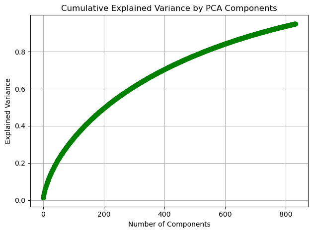

```python
# PCA dimensionality reduction
pca = PCA(n_components=0.95)

X_train_pca = pca.fit_transform(X_train.toarray())
X_test_pca = pca.transform(X_test.toarray())

# Visualize explained variance
plt.plot(np.cumsum(pca.explained_variance_ratio_), marker='o', color='green')
plt.title("Cumulative Explained Variance by PCA Components")
plt.xlabel("Number of Components")
plt.ylabel("Explained Variance")
plt.grid(True)
plt.tight_layout()
plt.show()
```

"PCA Reduction" compresses the TF_IDF features into fewer dimensions, but I set it here to retain 95% of the variance.

I would also like to bring attention to the utilization of the PCA Reduction. Initially, I intended to use TF-IDF and Ridge Regression, but I encountered a highly correlated and sparse feature space after its application. Ridge, even when I added regularization, assigned near-zero weights, which I saw as an "alphabetical" sorting symptom in the output. This output didn't provide the useful insight that I would be confident presenting to a company such as Honda to drive data-driven change in their organization.

To address the "alphabetical" sorting symptom, I incorporated PCA to reshape the TF-IDF feature space. PCA was fed the Ridge signal from TF-IDF, allowing Ridge to generalize better, explain the rating variance concisely, and provide output that I could reasonably draw meaningful insights from the patterns in the rating variance.

```python
# Ridge Regression

ridge = Ridge(alpha=0.1) # Utilizing less agressive regularization
ridge.fit(X_train_pca, y_train)
y_pred = ridge.predict(X_test_pca)
```

I utilize "Ridge Regression" to fit a less aggressive, 0.1, linear model to predict user ratings.

```python
# Model evaluation

mse = mean_squared_error(y_test, y_pred)
r2 = r2_score(y_test, y_pred)

# Quantify model performance
print(f"Mean Squared Error: {mse:.2f}")
print(f"R2 Score: {r2:.2f}")
```

```
Mean Squared Error: 0.48
R2 Score: 0.40
```

I decided to utilize Mean Squared Error (MSE) and R$ ^2 $ score because they are suited for user ratings, a continuous target, giving insight into predictive error and variance.

The MSE of 0.48 reveals that, on average, model predictions deviate from the true rating. The deviation is approximately $ \pm $ 0.7, RMSE = $ \sqrt 0.48 $ = 0.69 = 0.7 (rounded up). The 0.7 is pretty tight since ratings are on a 1 to 5 scale.

The R$ ^2 $ score of 0.40 explains 40% of the variance in the ratings based on TF-IDF signals + PCA compression. This is nontrivial and shows that I am capturing a meaningful signal despite dimensionality reduction.

```python
# Identify influential words

# Get PCA components
components = pca.components_

# Get feature names
feature_names = vectorizer.get_feature_names_out()

def top_words(component_vector, feature_names, top_n=20):
    indices = np.argsort(component_vector)[-top_n:]
    return[(feature_names[i], component_vector[i]) for i in reversed(indices)]

# Top words from first 3 PCA components
for i in range(3):
    print(f"\nTop words for PCA Components {i+1}:")
    for word, weight in top_words(components[i], feature_names):
        print(f"{word}: {weight:.2f}")
```

```
Top words for PCA Components 1:
great: 0.34
car: 0.25
fun: 0.16
love: 0.16
drive: 0.15
gas: 0.15
mileage: 0.15
mpg: 0.14
good: 0.11
comfortable: 0.09
seats: 0.07
driving: 0.07
room: 0.07
little: 0.06
ride: 0.06
better: 0.06
nice: 0.06
handles: 0.06
fit: 0.06
excellent: 0.06

Top words for PCA Components 2:
car: 0.72
miles: 0.22
bought: 0.14
great: 0.13
new: 0.13
ive: 0.11
years: 0.10
oil: 0.10
civic: 0.10
maintenance: 0.08
accord: 0.07
reliable: 0.07
honda: 0.06
problems: 0.06
owned: 0.06
replaced: 0.05
fun: 0.05
```

[output cut: 10 more lines]

```
driving: 0.16
city: 0.15
hybrid: 0.13
average: 0.12
oil: 0.09
trip: 0.09
tank: 0.09
tires: 0.09
mph: 0.09
better: 0.08
civic: 0.08
town: 0.08
good: 0.08
drive: 0.07
fuel: 0.07
```

"Identify influential words" operates to interpret what each PCA component "means". This is done by surfacing highly weighted words.

Component 1 has a theme of "user sentiment and driving experience", seen as fun, love, and comfortable.

Component 2 has a theme of "ownership history", seen as seen as miles, great, years, and maintenance.

Component 3 has a theme of "fuel efficiency", seen as mpg, gas, hybrid, and average.

These separations are excellent to see as each vector appears to be capturing distinct semantic clusters. This means the TF-IDF and PCA pipeline are preserving meaningful variance and removing noise.

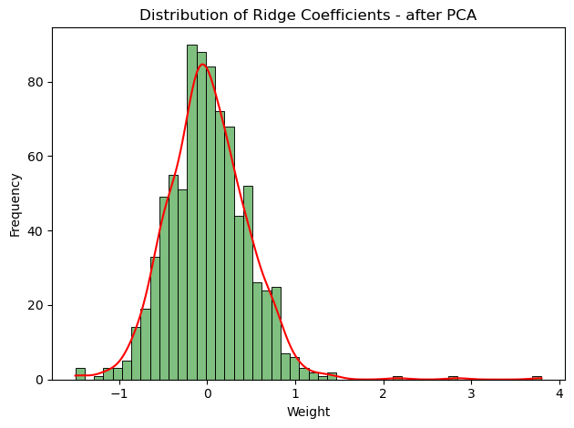

```python
# Visualize PCA features

sns.histplot(ridge.coef_, bins=50, kde=True, color="green")
plt.title("Distribution of Ridge Coefficients - after PCA")
plt.xlabel("Weight")
plt.ylabel("Frequency")
plt.tight_layout()
plt.gca().lines[0].set_color("red")
plt.show()
```

The histogram "Distribution of Ridge Coefficients - after PCA" shows that most weights are near zero. This is great because we know that regularization and PCA are doing their job, most components have minimal influence and control overfitting.

The distribution is slightly positive, suggesting a bias toward positive contributions. This may indicate a more constructive signal from components.

The right side tail hints at a small number of components driving the predictions significantly and may be great for interpretation of feature diagnostics.

Ultimately, PCA was successful, more so than Ridge Regression alone, in compacting the TF-IDF, and Ridge isn't swamped with noisy features.